# Linear models and ANOVA in R

## The model

**Data = Model + Error**

body mass = β<sub>0</sub> + β<sub>1</sub> · Chinstrap + β<sub>2</sub> · Gentoo + ε

Chinstrap = 1 for Chinstrap penguins, 0 for all others (same for Gentoo)

- **β<sub>0</sub>**: mean of Adelie, the **reference** group
- **β<sub>1</sub>, β<sub>2</sub>**: differences to Adelie

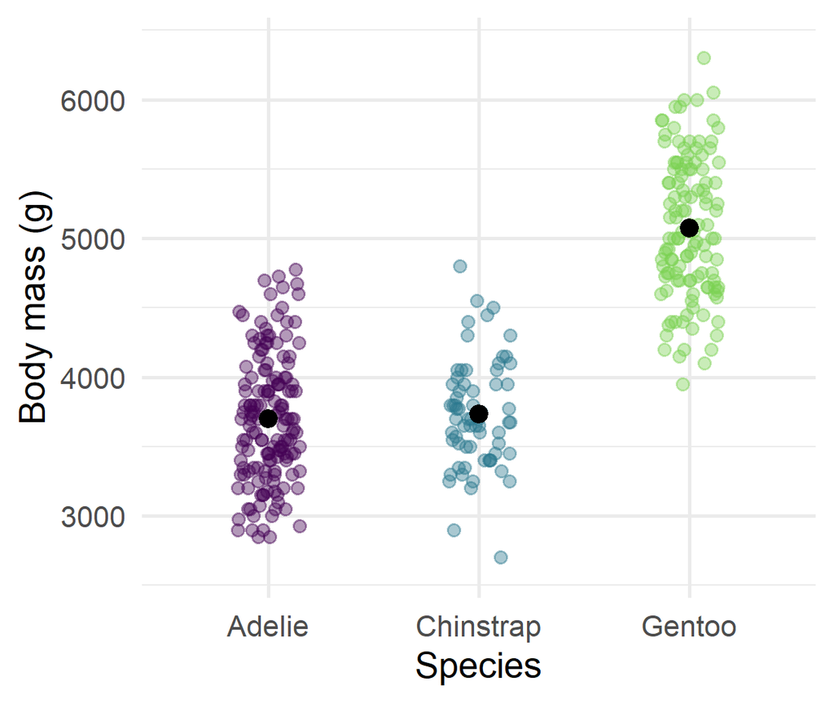

[figure not shown]

[figure not shown]

## Fit the model

```r
m_anova <- lm(body_mass_g ~ species, data = penguins)
```

## Check model assumptions

```r
performance::check_model(m_anova)
```

## Check model assumptions

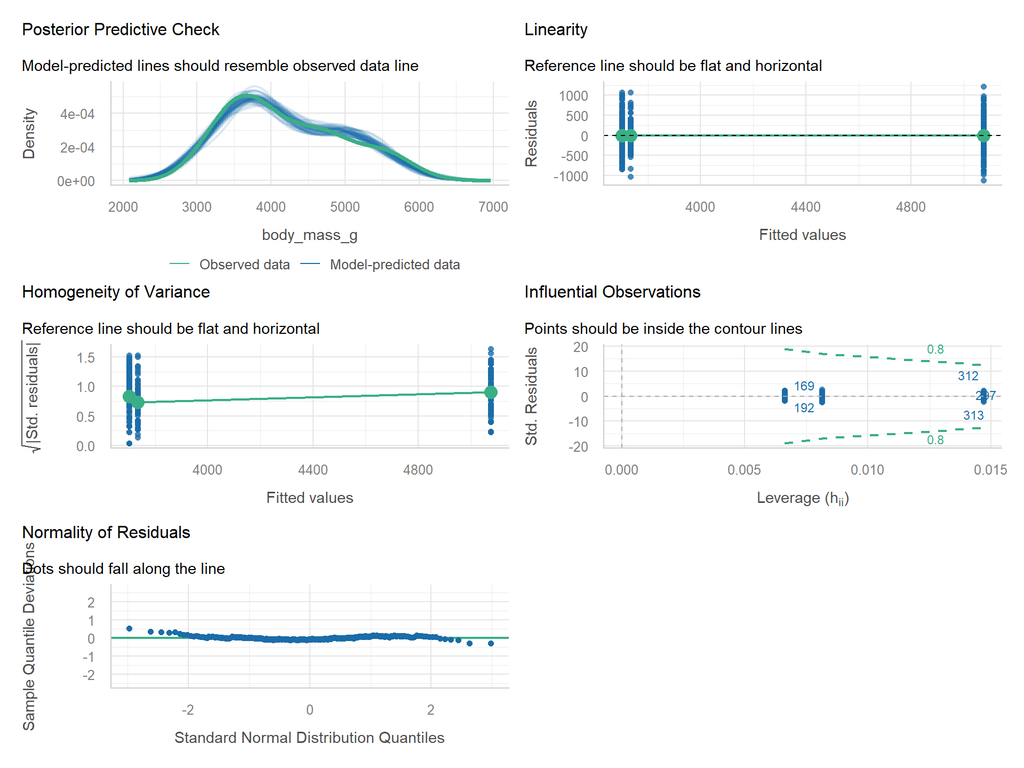

## How big are the differences?

```r
summary(m_anova)
```

```
Call:
lm(formula = body_mass_g ~ species, data = penguins)

Residuals:
     Min       1Q   Median       3Q      Max
-1126.02  -333.09   -33.09   316.91  1223.98

Coefficients:
                 Estimate Std. Error t value Pr(>|t|)
(Intercept)       3700.66      37.62   98.37   <2e-16 ***
speciesChinstrap    32.43      67.51    0.48    0.631
speciesGentoo     1375.35      56.15   24.50   <2e-16 ***
---
Signif. codes:  0 '***' 0.001 '**' 0.01 '*' 0.05 '.' 0.1 ' ' 1

Residual standard error: 462.3 on 339 degrees of freedom
  (2 observations deleted due to missingness)
Multiple R-squared:  0.6697,    Adjusted R-squared:  0.6677
F-statistic: 343.6 on 2 and 339 DF,  p-value: < 2.2e-16
```

- `(Intercept)`: mean of Adelie, the reference (3701 g)
- `speciesChinstrap`, `speciesGentoo`: differences to Adelie (+32 g, +1375 g)

## How much evidence is there for an effect?

```r
car::Anova(m_anova)
```

```
Anova Table (Type II tests)

Response: body_mass_g
             Sum Sq  Df F value    Pr(>F)
species   146864214   2  343.63 < 2.2e-16 ***
Residuals  72443483 339
---
Signif. codes:  0 '***' 0.001 '**' 0.01 '*' 0.05 '.' 0.1 ' ' 1
```

- `species`: does species matter **as a whole** factor?
- `Residuals`: error that’s left after accounting for the effect of species

Result: Strong evidence that body mass differs between species (F<sub>2,339</sub> = 343.6, p < 0.001).

## Mean body mass per species

```r
library(emmeans)
# mean estimate separately for each species
emm <- emmeans(m_anova, ~species)
emm
```

```
 species   emmean   SE  df lower.CL upper.CL
 Adelie      3701 37.6 339     3627     3775
 Chinstrap   3733 56.1 339     3623     3843
 Gentoo      5076 41.7 339     4994     5158

Confidence level used: 0.95
```

- `emmeans()` (package `emmeans`): mean and 95% CI for each group, from the model

## Which species differ?

Use the `pairs()` function to compare all species pairs.

```r
pairs(emm, reverse = TRUE, infer = TRUE)
```

```
 contrast           estimate   SE  df lower.CL upper.CL t.ratio p.value
 Chinstrap - Adelie     32.4 67.5 339     -127      191   0.480  0.8807
 Gentoo - Adelie      1375.4 56.1 339     1243     1508  24.495 <0.0001
 Gentoo - Chinstrap   1342.9 69.9 339     1178     1507  19.224 <0.0001

Confidence level used: 0.95
Conf-level adjustment: tukey method for comparing a family of 3 estimates
P value adjustment: tukey method for comparing a family of 3 estimates
```

- One row per pair: difference (how big?), CI (how precise?), p-value (how much evidence?)
- P-values and CIs are **Tukey-adjusted** for multiple comparisons

## Show the model

Use the results from `emmeans()` to show the means and 95% CI of the means on top of the data.

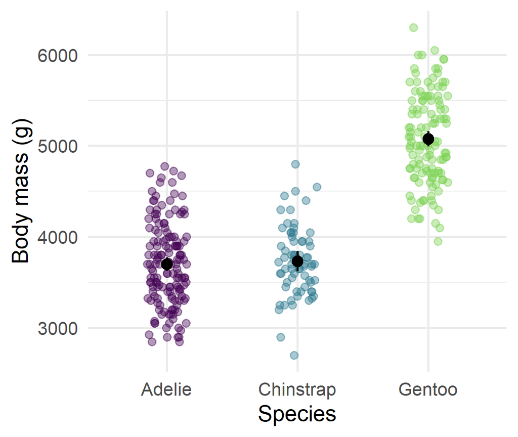

```r
ggplot(penguins, aes(x = species, y = body_mass_g)) +
  geom_jitter(
    aes(color = species),
    width = 0.15,
    height = 0,
    alpha = 0.4
  ) +
  geom_pointrange(
    data = as_tibble(emm),
    aes(y = emmean, ymin = lower.CL, ymax = upper.CL),
    size = 0.7,
    linewidth = 1
  ) +
  scale_color_viridis_d(end = 0.8) +
  labs(x = "Species", y = "Body mass (g)") +
  theme(legend.position = "none")
```

## Report the results

> Body mass differed between species (F<sub>2,339</sub> = 343.6, p < 0.001). Gentoo were heavier than Adelie (1375 g, 95% CI 1243–1508, p < 0.001) and Chinstrap (1343 g, 95% CI 1178–1507, p < 0.001), whereas we found no evidence of a difference between Chinstrap and Adelie (32 g, 95% CI −127 to 191, p = 0.88).

## Linear model step by step

| Step | Linear regression | ANOVA |
| --- | --- | --- |
| **Question** | How much heavier are penguins with longer flippers? | How much does body mass differ between species? |
| **Fit model** | `lm(body_mass_g ~ flipper_length_mm)` | `lm(body_mass_g ~ species)` |
| **Check assumptions** | `performance::check_model()` | `performance::check_model()` |
| **Answer** | `summary()`, `confint()`, `car::Anova()` | `car::Anova()`, `emmeans()`, `pairs()` |
| **Show** | `geom_smooth(method = "lm")` or `augment()` | Data + means and 95% CI from `emmeans()` |
| **Report** | Effect, 95% CI, F, p, R² | F, p, and each difference with 95% CI and p |

## Your turn

> ✏️ **Exercise 2 (~10 min):**

> Open `exercises/02_anova_exercise.R`

# ANCOVA

> continuous and categorical predictor

## Does the relationship differ between species?

- **Expectation:** Body mass increases with flipper length in all species
- **Question:** Is the increase the same for all species?

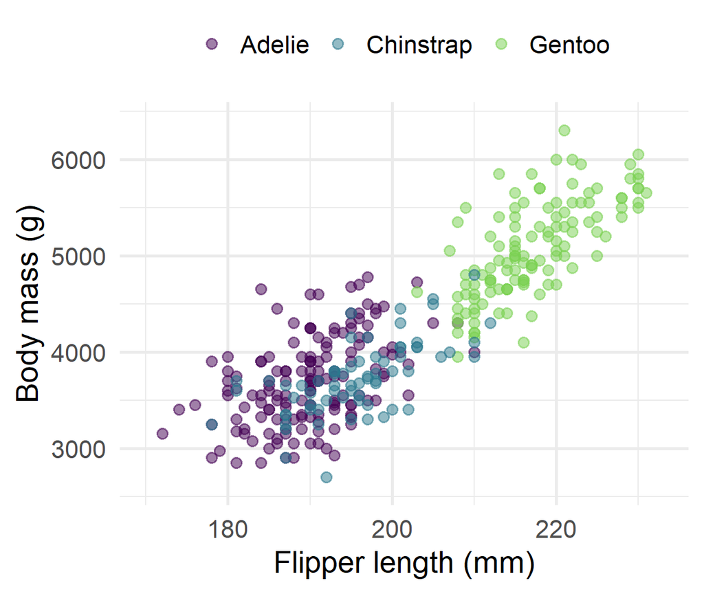

## Two possible models

**Without interaction:** parallel lines

Flipper length and species have an effect

body mass = β<sub>0</sub> + β<sub>1</sub> · flipper + β<sub>2</sub> · Chinstrap + β<sub>3</sub> · Gentoo + ε

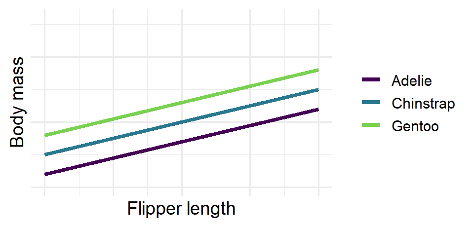

**With interaction:** different slopes

Effect of flipper length differs between species

body mass = β<sub>0</sub> + β<sub>1</sub> · flipper + β<sub>2</sub> · Chinstrap + β<sub>3</sub> · Gentoo + β<sub>4</sub> · flipper · Chinstrap + β<sub>5</sub> · flipper · Gentoo + ε

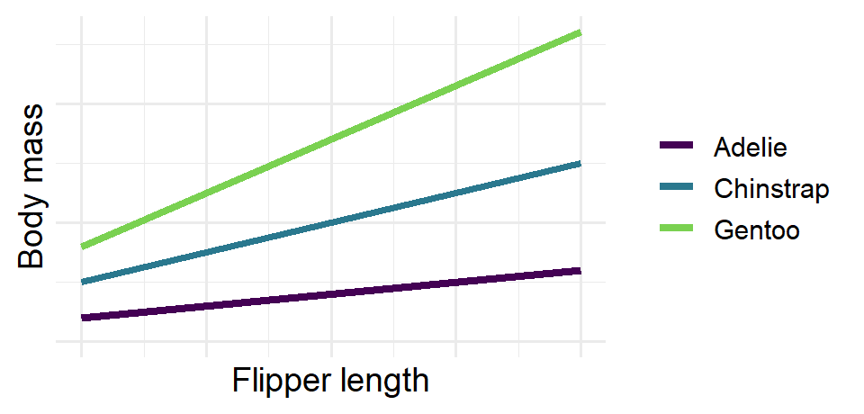

## Fit the models

Without interaction

```r
m_add <- lm(
  body_mass_g ~ flipper_length_mm + species,
  data = penguins
)
```

With interaction

```r
m_int <- lm(
  body_mass_g ~ flipper_length_mm + species + flipper_length_mm:species,
  data = penguins
)
```

- `flipper_length_mm:species` is the interaction.
  - Short version: `flipper_length_mm * species` (R expands it to main effects + all interactions)
- Never fit an interaction without its main effects

## Check the assumptions

```r
performance::check_model(m_int)
```

- Same checks as before
- High collinearity is expected with an interaction

## Check the assumptions

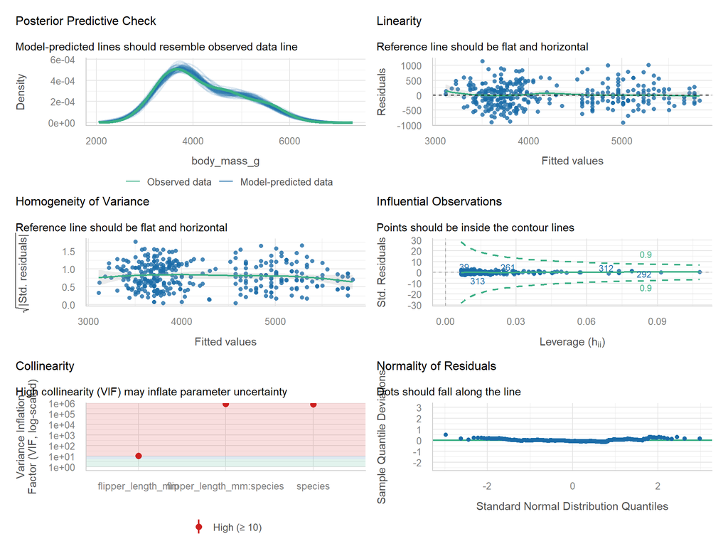

## How much evidence for an interaction?

```r
car::Anova(m_int)
```

```
Anova Table (Type II tests)

Response: body_mass_g
                            Sum Sq  Df F value    Pr(>F)
flipper_length_mm         24776495   1 180.398 < 2.2e-16 ***
species                    5187807   2  18.886 1.686e-08 ***
flipper_length_mm:species  1519564   2   5.532  0.004327 **
Residuals                 46147424 336
---
Signif. codes:  0 '***' 0.001 '**' 0.01 '*' 0.05 '.' 0.1 ' ' 1
```

- `flipper_length_mm:species`: do the slopes differ between species? Compares the models with and without the interaction
- If the interaction matters, don’t interpret the main effects on their own

Result: Evidence that the relationship differs between species (F<sub>2,336</sub> = 5.5, p = 0.004).

## Which slopes differ?

```r
# slope estimates for flipper length separate per species
slopes <- emtrends(m_int, ~species, var = "flipper_length_mm")
slopes
```

```
 species   flipper_length_mm.trend   SE  df lower.CL upper.CL
 Adelie                       32.8 4.63 336     23.7     41.9
 Chinstrap                    34.6 6.35 336     22.1     47.1
 Gentoo                       54.6 5.17 336     44.4     64.8

Confidence level used: 0.95
```

```r
pairs(slopes, reverse = TRUE, infer = TRUE)
```

```
 contrast           estimate   SE  df lower.CL upper.CL t.ratio p.value
 Chinstrap - Adelie     1.74 7.86 336  -16.752     20.2   0.222  0.9733
 Gentoo - Adelie       21.79 6.94 336    5.450     38.1   3.139  0.0052
 Gentoo - Chinstrap    20.05 8.19 336    0.769     39.3   2.448  0.0394

Confidence level used: 0.95
Conf-level adjustment: tukey method for comparing a family of 3 estimates
P value adjustment: tukey method for comparing a family of 3 estimates
```

- Same as in ANOVA, but with slopes instead of means

## Show the model

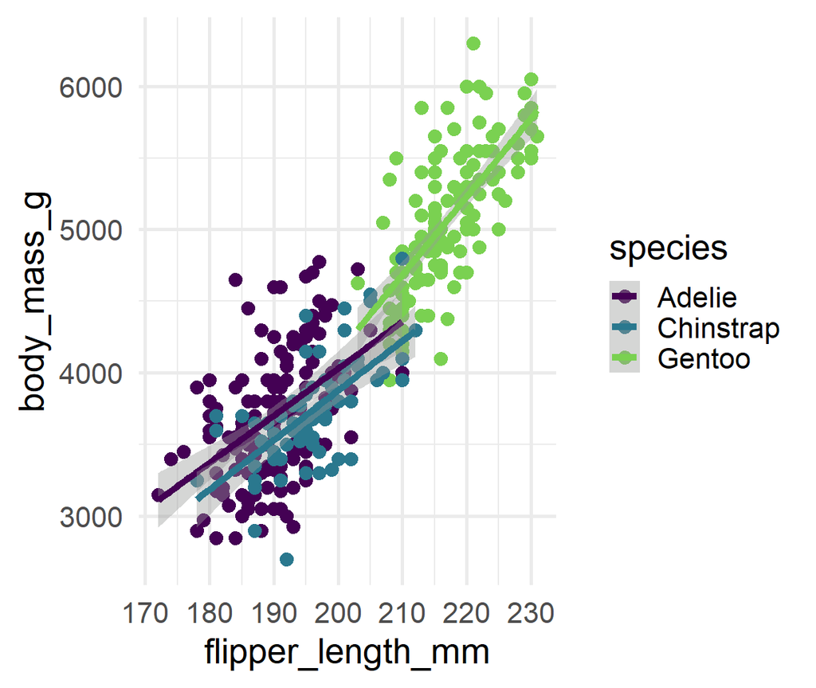

```r
ggplot(
  penguins,
  aes(
    x = flipper_length_mm,
    y = body_mass_g,
    color = species
  )
) +
  geom_point() +
  geom_smooth(method = "lm") +
  scale_color_viridis_d(end = 0.8)
```

- With `color = species`, `geom_smooth()` fits one line per species: the interaction model

## Report the results

> The relationship between flipper length and body mass differed between species (interaction: F<sub>2,336</sub> = 5.5, p = 0.004). The slope was steeper in Gentoo than in Adelie (21.8 g per mm, 95% CI 5.5–38.1, p = 0.005) and Chinstrap (20.1 g per mm, 95% CI 0.8–39.3, p = 0.04), whereas we found no evidence of a difference between Chinstrap and Adelie (1.7 g per mm, 95% CI −16.8 to 20.2, p = 0.97).

## Little evidence for an interaction?

- Report the interaction test
- Use the model without interaction (`m_add`), same steps as before

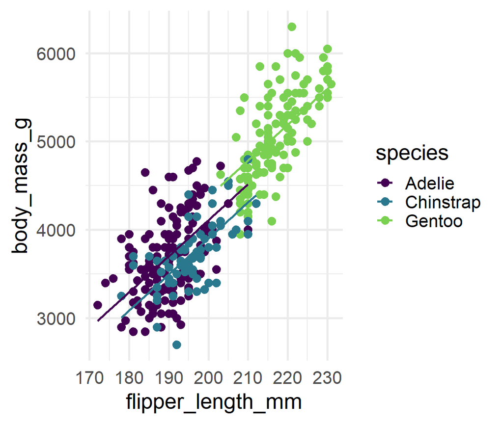

```r
pred_add <- augment(m_add, interval = "confidence")

ggplot(
  pred_add,
  aes(
    x = flipper_length_mm,
    y = body_mass_g,
    color = species
  )
) +
  geom_point() +
  geom_line(aes(y = .fitted)) +
  scale_color_viridis_d(end = 0.8)
```

## Linear model step by step

| Step | Linear regression | ANOVA | ANCOVA |
| --- | --- | --- | --- |
| **Fit model** | `~ flipper_length_mm` | `~ species` | `~ flipper_length_mm * species` |
| **Check** | `check_model()` | `check_model()` | `check_model()` |
| **Answer** | `summary()`, `confint()`, `car::Anova()` | `car::Anova()`, `emmeans()`, `pairs()` | `car::Anova()`, `emtrends()`, `pairs()` |
| **Show** | `geom_smooth()` or `augment()` | Data + means from `emmeans()` | `geom_smooth()`, or `augment()` for the additive model |
| **Report** | Effect, 95% CI, F, p, R² | F, p, differences (95% CI, p) | Interaction F, p, slope differences (95% CI, p) |

## Your turn

> ✏️ **Exercise 3 (~10 min):**

> Open `exercises/03_ancova_exercise.R`

# Wrap-up

## What makes all these models linear?

| Model | Formula |
| --- | --- |
| Regression | body mass = β<sub>0</sub> + β<sub>1</sub> · flipper length + ε |
| ANOVA | body mass = β<sub>0</sub> + β<sub>1</sub> · Chinstrap + β<sub>2</sub> · Gentoo + ε |
| ANCOVA | body mass = β<sub>0</sub> + β<sub>1</sub> · flipper length + β<sub>2</sub> · Chinstrap + β<sub>3</sub> · Gentoo + ε |

A **linear combination**: each predictor is multiplied with a parameter, and everything is added up

Not linear would e.g. be:

- A parameter in the exponent (e.g. exponential decay): y = β<sub>0</sub> · exp(β<sub>1</sub> · x) + ε
- A parameter in the denominator (e.g. saturation curves): y = β<sub>0</sub> · x / (β<sub>1</sub> + x) + ε

## Correlation is not causation

- We often use causal langauge (“A causes B”, “A has an effect on B”) but it’s not always a cause
- Choose your words carefully: “association” or “is related to” instead of “causes” might be more appropriate
- Controlled experiments make causal claims easier than field observations

[figure not shown]

Image: 9gag

## Choose your predictors carefully

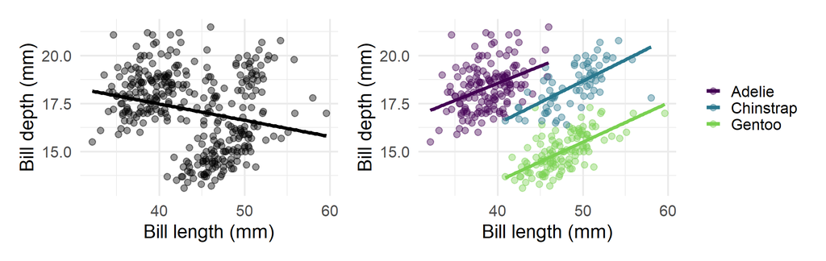

- Leaving out a predictor can change the answer a lot
- Choose the model structure and predictors from your research question and what you know about the data

## The p-value is not everything

- Report the **effect size** and its **CI**, not only the p-value
- Significant does not mean relevant
- Not significant does not mean no effect

## Where next: more complex models

You can combine as many predictors in your models as your data allows.

```r
# two-way ANOVA
lm(body_mass_g ~ species + sex + species:sex, data = penguins)

# even more predictors
lm(
  body_mass_g ~ flipper_length_mm + bill_length_mm + species + sex,
  data = penguins
)
```

- The workflow stays the same: fit, check, answer, show, report
- Coefficients are harder to interpret: use `emmeans()`, `emtrends()` and plots

## When model assumptions are violated

- Exponential relationships: you can often **log-transform** the response and use `lm()`
- Data not independent (repeated measures, several measurements per animal or site) → **mixed models** with random effects (`lme4`)
- Counts, proportions, yes/no → **GLM** (`glm()`): a different distribution instead of the normal distribution

## Resources

- R packages: [`palmerpenguins`](https://allisonhorst.github.io/palmerpenguins/), [`performance`](https://easystats.github.io/performance/), [`car`](https://cran.r-project.org/package=car), [`emmeans`](https://rvlenth.github.io/emmeans/), [`broom`](https://broom.tidymodels.org/)
- Book: [Statistical Modelling: Lecture Notes for From Data to Evidence](https://bookdown.org/btmarti25/FD2E/) by Benjamin T. Martin

Thanks to Felix May and Felix Nößler for sharing their course materials.

## Next lecture/workshop

#### Topic: tba

📅 21.01.2027 🕓 4-5 p.m. 📍 Webex

🔔 [Subscribe to the mailing list](https://lists.fu-berlin.de/listinfo/toolsAndTips)

📧 For topic suggestions and/or feedback send me an email

# The end :)